# The OECD Programme for International Student Assessment: How some non-personal factors might affect the final scores

## by Abdelhamid Tebba

## Investigation Overview

In this exploration, I wanted to know the variables that might help explain the scores obtained by students in reading, maths and science. In this regard, I used both quantitative and qualitative variables that I have grouped into two categories: personal facors and environmental factors. But my main focus was on three categorical variables: gender, country groups and parents working status.

## Dataset Overview

The PISA2012 dataset contains more than 600 variables and 485490 observations. I reduced this data set to 21 variables, selected after reading the 2012 PISA Report. This rearranged and cleaned dataset include, inter alia, the following features: the scores obtained, the contry group (OECD or Non-OECD), the gender, the current occupation status of both parents, the economic and social index and the average time spent at school on the three assessed subjects.

## Distribution of PISA scores:

The average score, taken as the mean of three plausible values in reading, science and maths, is normally disributed with the mean around 500. The lower and upper bounds of this distribution are respectively 29.9 points and 875.8 points.

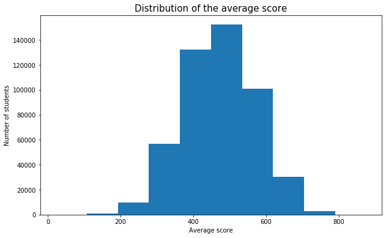

```python
plt.figure(figsize=[10,6])
plt.hist(data=pisa_sub, x='average_score')
plt.title('Distribution of the average score', size=15);
plt.xlabel('Average score', size=10)
plt.ylabel('Number of students', size=10)
plt.show();
```

## Distribution of PISA scores by country group:

OECD countries have higher average scores than Non-OECD countries. This shows how belonging to the OECD club, whose members are developed countries, has an effect on the PISA scores. It may be consistent with the fact that OECD countries have a better education system.

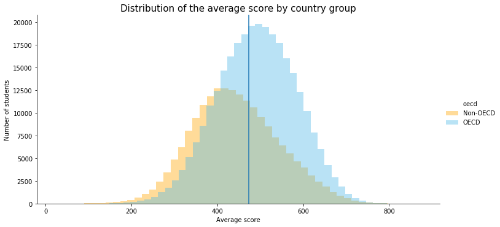

```python
g = sb.FacetGrid(data=pisa_sub_new, hue='oecd', palette={'OECD': '#50b8e7', 'Non-OECD':'#FFA500'}, height=5, aspect=2)
g.map(sb.distplot, 'average_score', kde=False)
plt.xlabel('Average score')
plt.ylabel('Number of students')
plt.title('Distribution of the average score by country group', size=15)
plt.axvline(x=pisa_sub_new['average_score'].mean())
g.add_legend();
```

## Scores in country groups by gender:

Overall, OECD countries have a higher school performance than Non-OECD countries in all three subjets, both for boys and girls. As for the score repartition by gender among these groups, female students in both OECD countries and Non-OECD countries perform well in reading as compared to boys, while in maths it is the opposite. This is not to imply that a sepcific gender is better but only to bring into attention this particular fact.

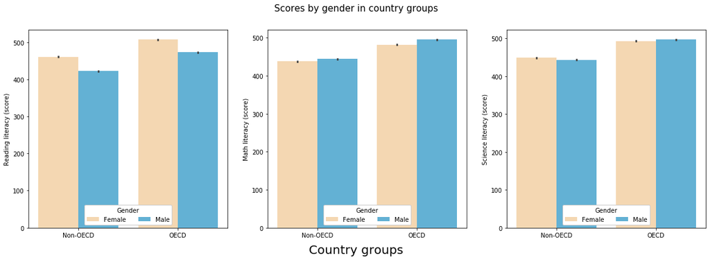

```python
fig, ax= plt.subplots(nrows=1,ncols=3,figsize=[20,6])
plt.suptitle('Scores by gender in country groups', size=20)
fig.text(0.5, 0.04, 'Country groups', va='center', ha='center', fontsize=15)
score_var= ['PV1READ', 'PV1MATH', 'PV1SCIE']
label = ['Reading literacy (score)', 'Math literacy (score)', 'Science literacy (score)']
i=0
for y, z in zip(score_var, label):
    sb.barplot(data=pisa_sub_new, x='oecd', y=y, hue='gender', ax=ax[i], palette={'Female': '#FFd8a7', 'Male':'#50b8e7'})
    ax[i].legend(loc=8, ncol=3, framealpha=1, title='Gender')
    ax[i].set_ylabel(z)
    ax[i].set_xlabel('')
    i+=1
```

## Scores in country groups by parents current occupation

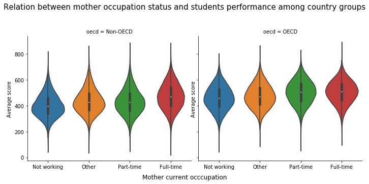

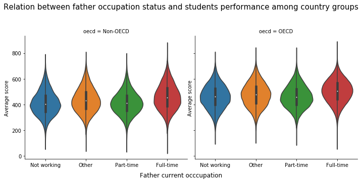

```python
job_order = ['Not working', 'Other', 'Part-time', 'Full-time']

plt.figure(figsize=[15,10])
g = sb.catplot(data=pisa_sub_new, x='mother_job', y='average_score', col='oecd', kind='violin',order=job_order)
g.set(xlabel='', ylabel='Average score')
plt.subplots_adjust(top=0.8)
g.fig.suptitle('Relation between mother occupation status and students performance among country groups', size=15)
g.fig.text(0.5, 0.03, 'Mother current occcupation', va='center', ha='center', fontsize=12)
plt.show();


plt.figure(figsize=[15,10])
f = sb.catplot(data=pisa_sub, x='father_job', y='average_score', col='oecd', kind='violin',order=job_order)
f.set(xlabel='', ylabel='Average score')
plt.subplots_adjust(top=0.8)
f.fig.suptitle('Relation between father occupation status and students performance among country groups', size=15)
f.fig.text(0.5, 0.03, 'Father current occcupation', va='center', ha='center', fontsize=12)
plt.show();
```